Lake Name: Butterfield Lake

Lake acreage: 969.6

County: JEFFERSON

PWLID: 0906-0020

Waterbody Classification: B

Coordinates: 44.316502,-75.7752

Is this waterbody a public water supply: No

Are there DOH desingated beaches on this waterbody: No

Open Water Indicators

2018 Sampling Results

Seasonal Change

05-28

06-10

06-25

07-08

07-23

08-05

08-19

09-02

Clarity (m)

4.45

6.55

5.45

5.80

3.80

3.95

3.35

2.65

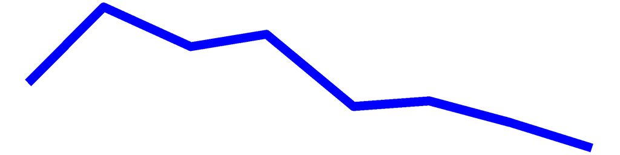

Surface TP (mg/L)

0.01

0.01

0.01

0.01

0.01

0.01

0.01

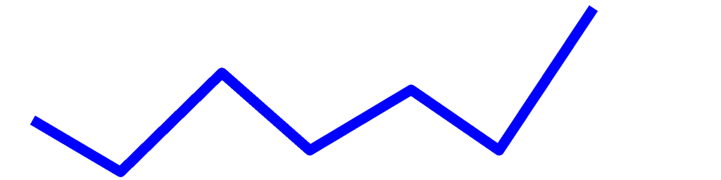

Surface TDP (mg/L)

0.01

0.00

0.01

0.01

0.01

0.01

0.01

0.00

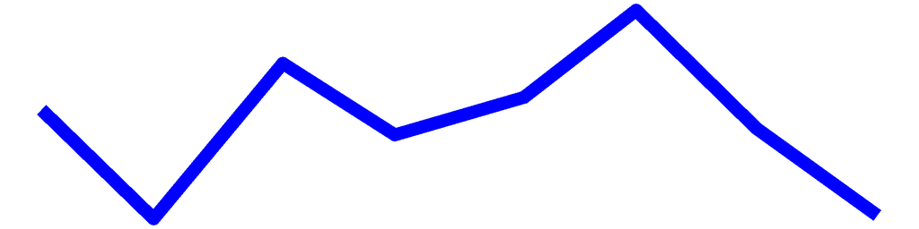

Deep TP (mg/L)

0.01

0.04

0.13

0.11

0.13

0.18

0.13

0.16

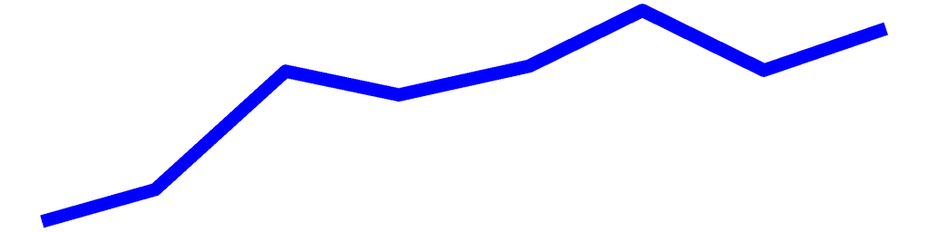

Deep TDP (mg/L)

0.01

0.02

0.12

0.03

0.13

0.05

0.04

0.08

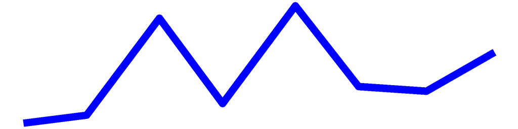

TN (mg/L)

0.58

0.43

0.48

0.42

0.49

0.52

0.46

0.45

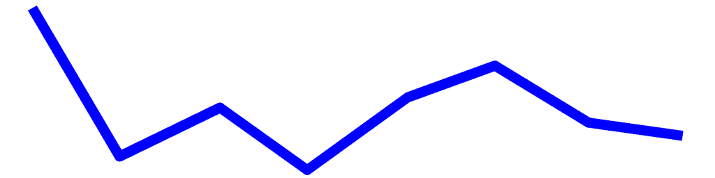

TDN (mg/L)

0.59

0.47

0.46

0.45

0.49

0.51

0.44

0.45

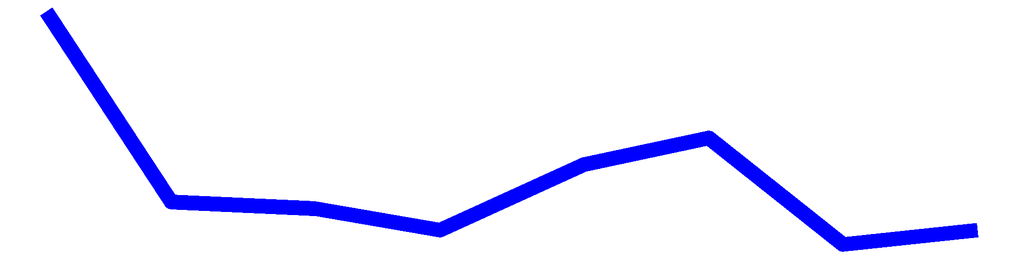

TN:TP

58.40

48.86

43.30

44.73

45.92

56.38

36.90

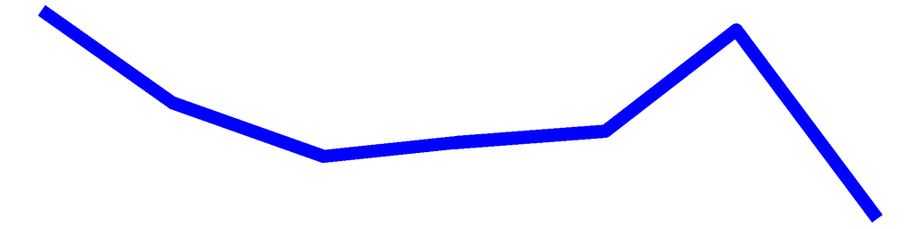

Surface NH3 (mg/L)

0.06

0.02

0.05

0.03

0.02

0.02

0.00

0.02

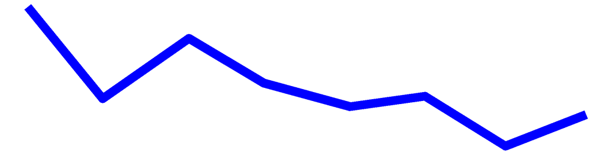

Deep NH3 (mg/L)

0.14

0.22

0.40

0.25

0.14

0.42

0.39

0.47

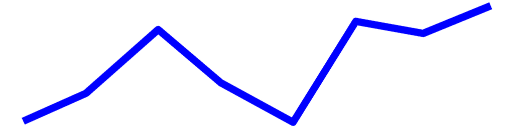

Chl.a (ug/L)

2.00

1.30

1.80

1.80

2.70

3.20

8.60

7.60

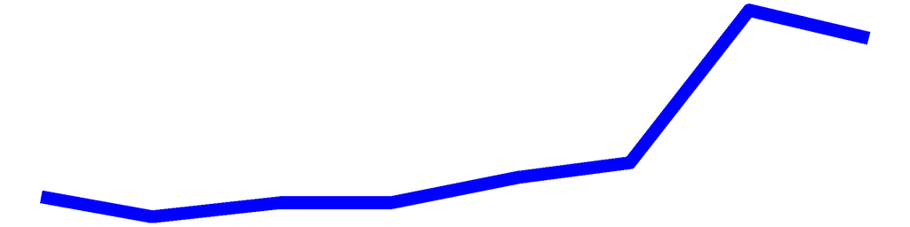

pH

7.58

7.83

7.91

8.09

7.45

7.70

7.05

7.68

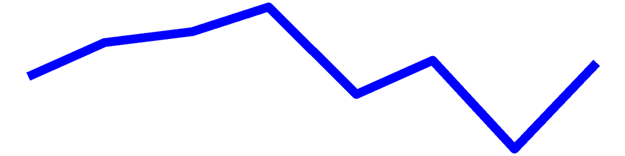

Cond (umho/cm)

164.00

152.60

139.50

141.70

141.90

107.90

127.00

130.10

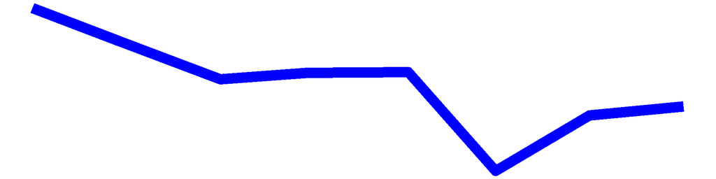

Surface Calcium (mg/L)

Bottom Calcium (mg/L)

Surface Chloride (mg/L)

20.30

18.30

Bottom Chloride (mg/L)

Upper Temp (degC)

19.00

20.00

23.00

25.00

25.00

25.00

25.00

23.00

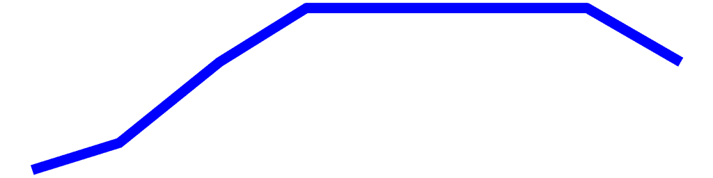

Deep Temp (degC)

9.00

9.00

9.00

10.00

10.00

10.00

10.00

10.00

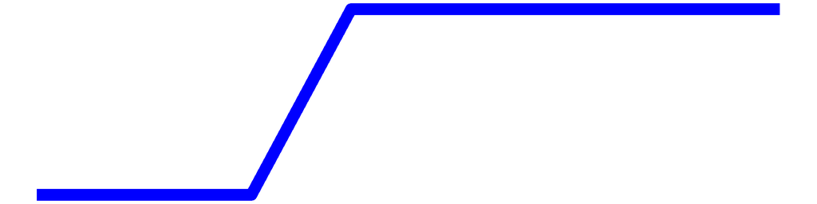

FP BG Chl.a (ug/L)

0.61

1.65

2.31

2.60

3.27

4.70

14.78

16.19

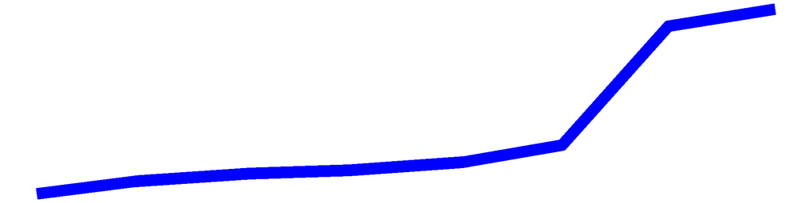

## Butterfield Lake – Sampling Season Results

### HABs Status

#### Open Water Algae

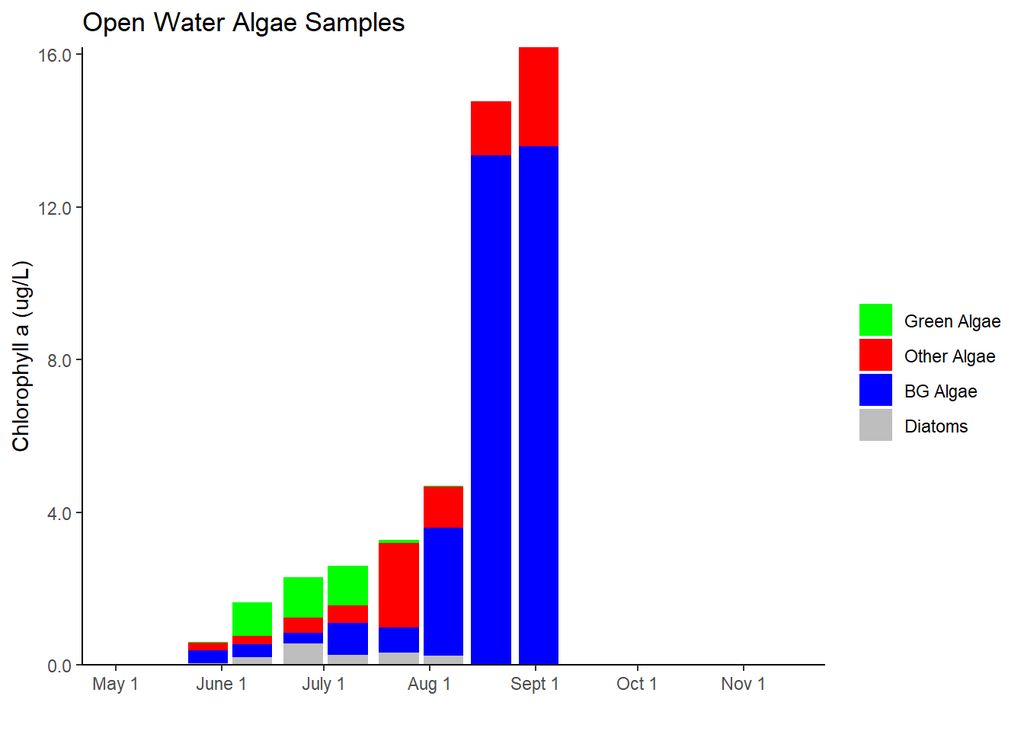

#### Shoreline Algae

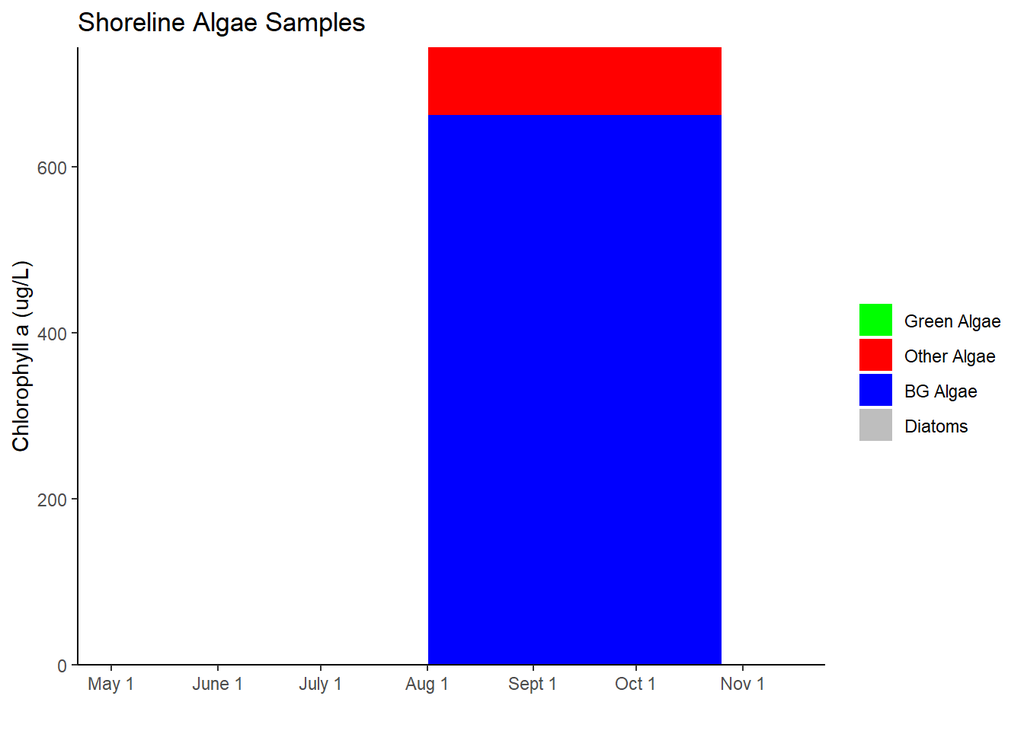

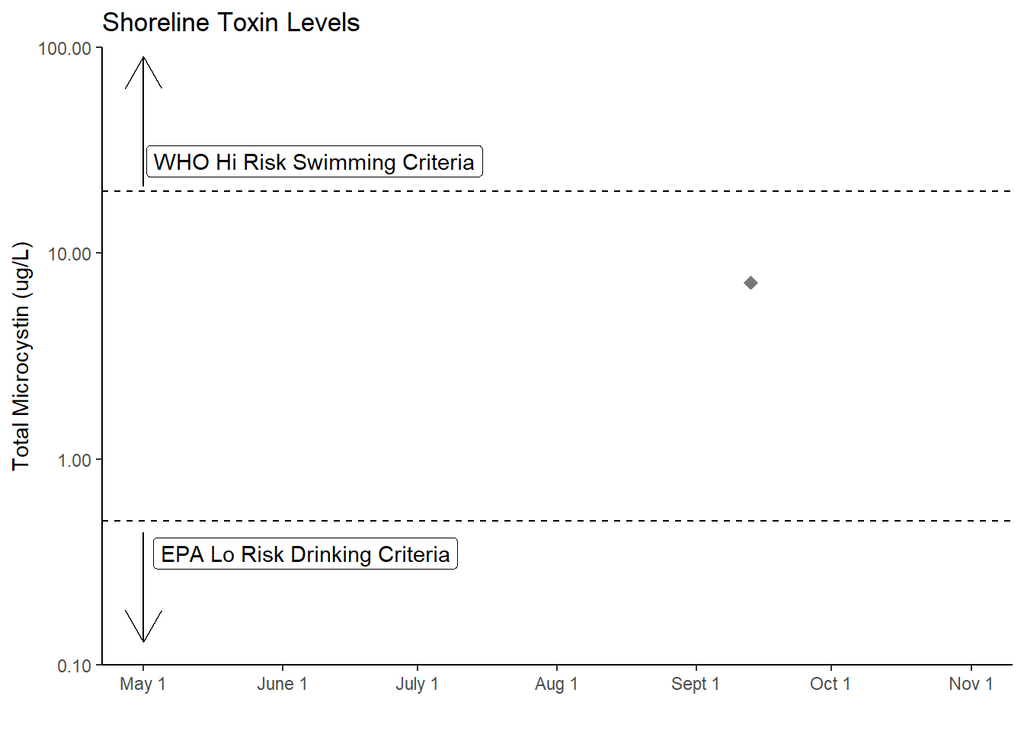

## Butterfield Lake Long-Term Trend Analysis

#### Clarity

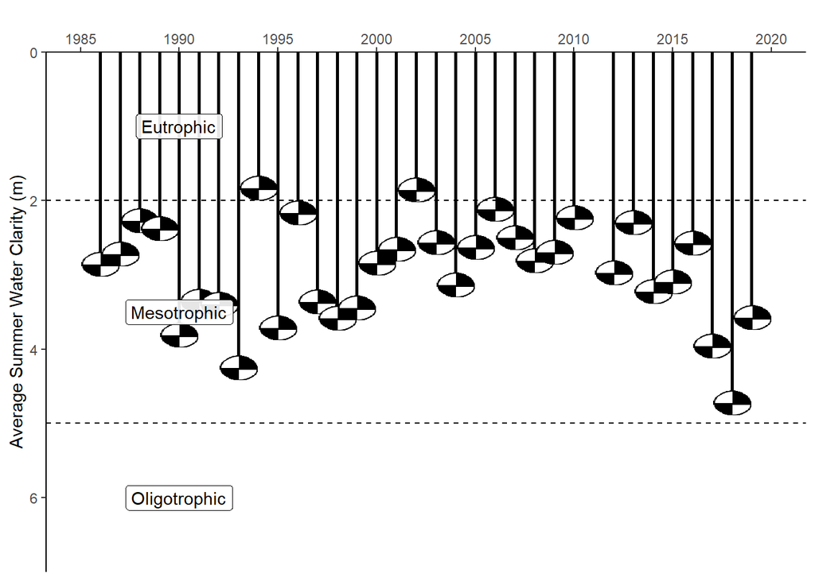

#### Chlorophyll *a*

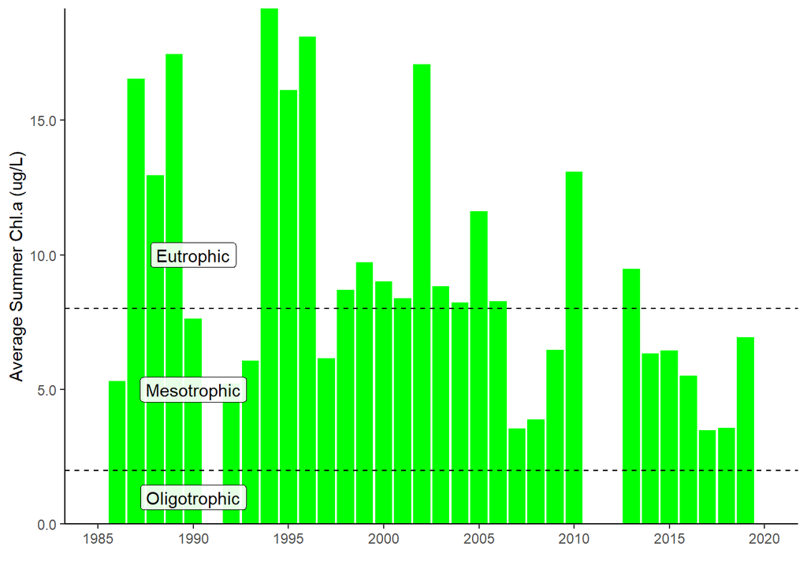

#### Surface and Deep Phosphorus

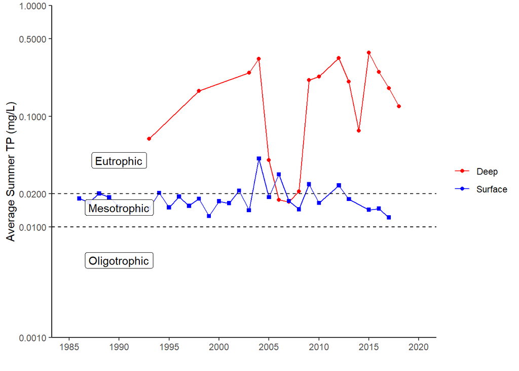

#### Nitrogen

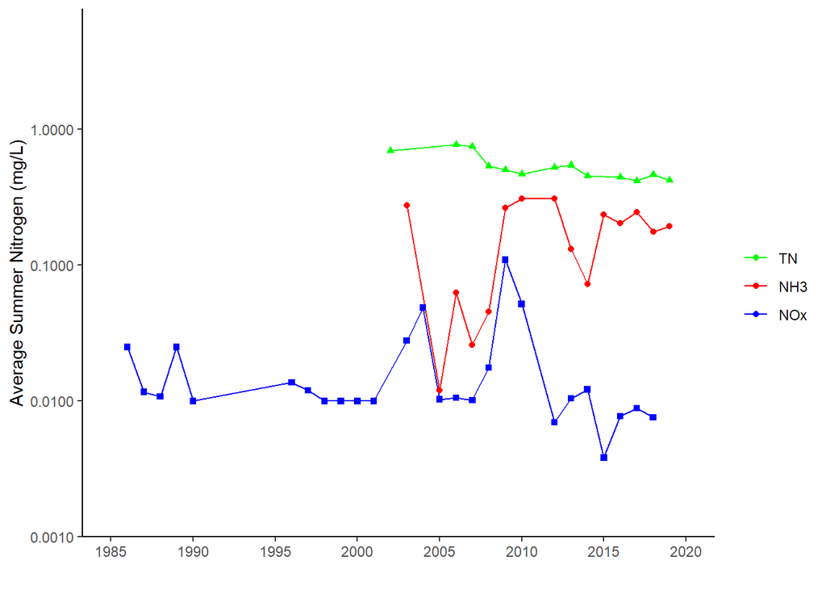

#### TN : TP

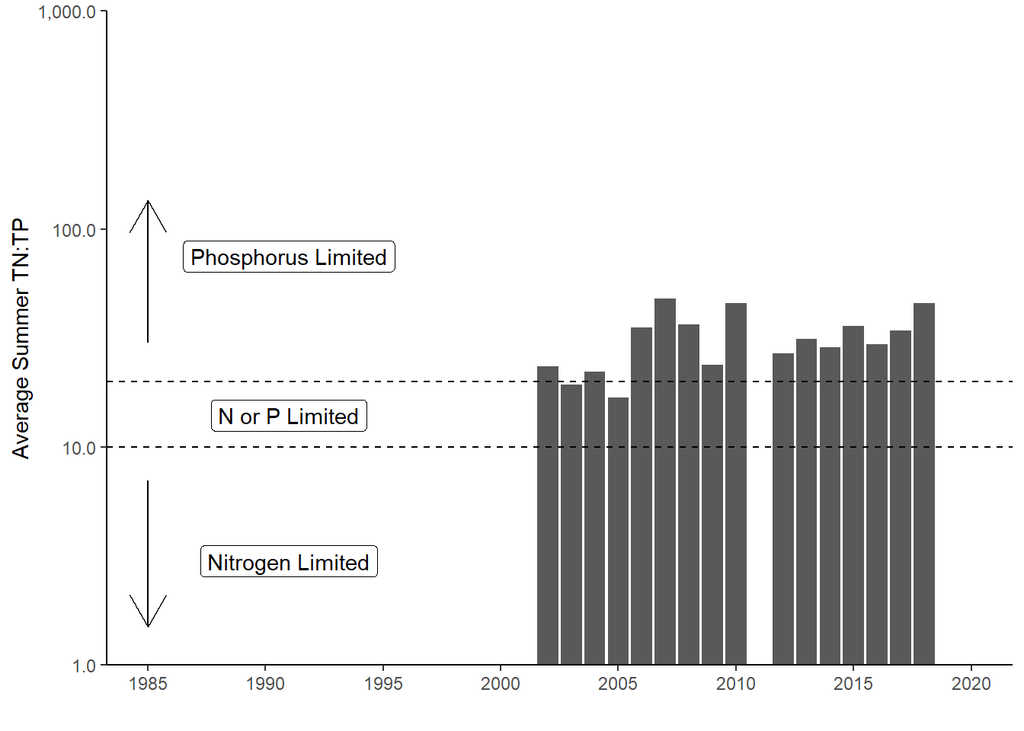

#### pH

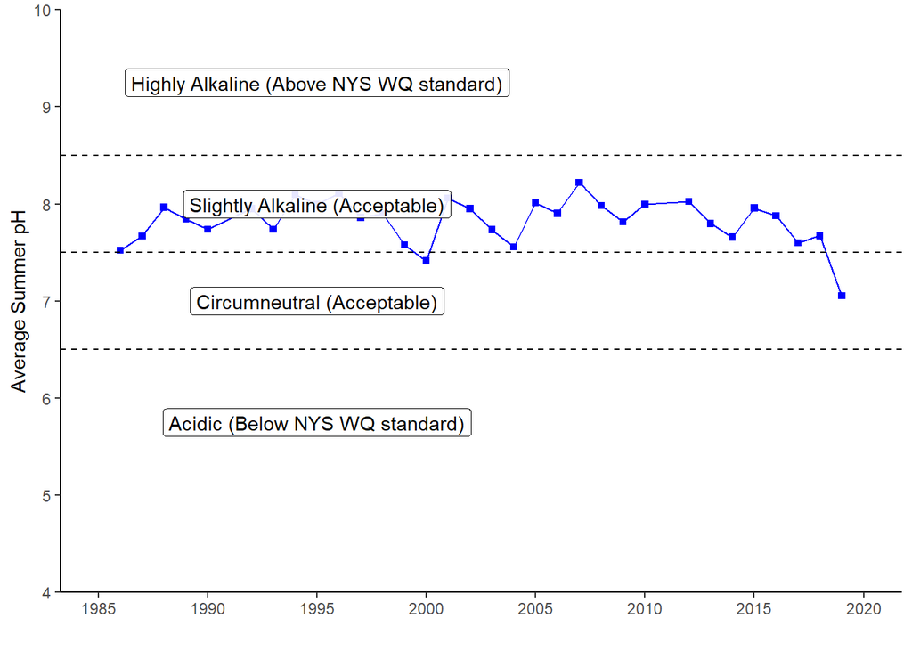

#### Specific Conductance

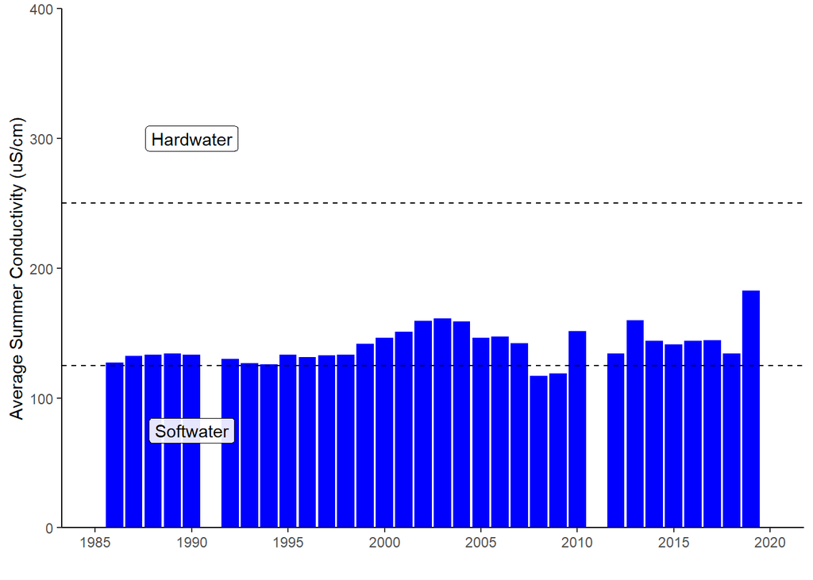

#### Calcium

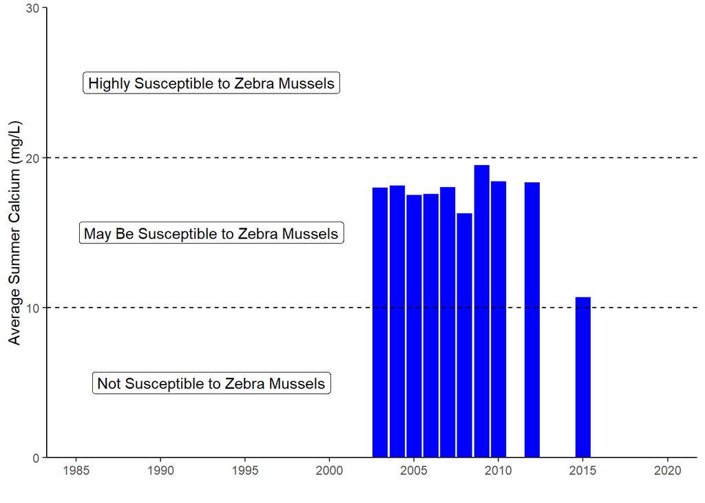

#### Chloride

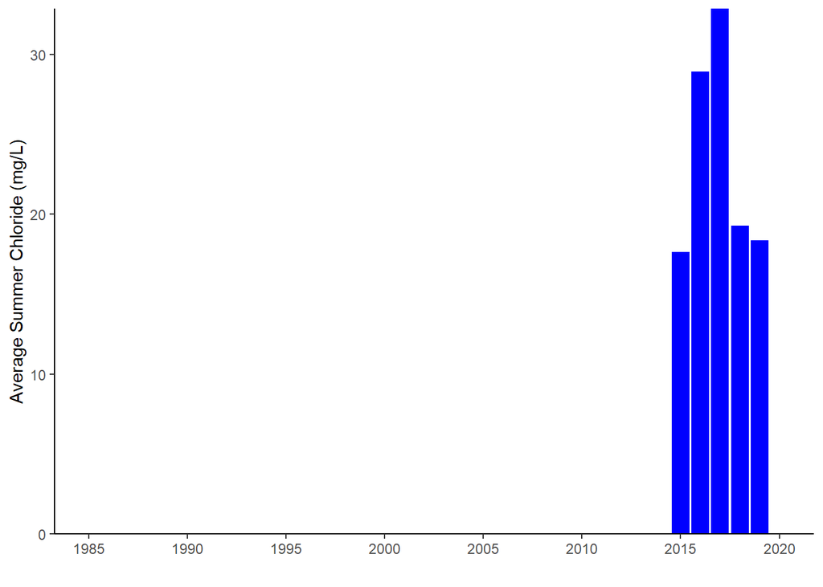

#### Color

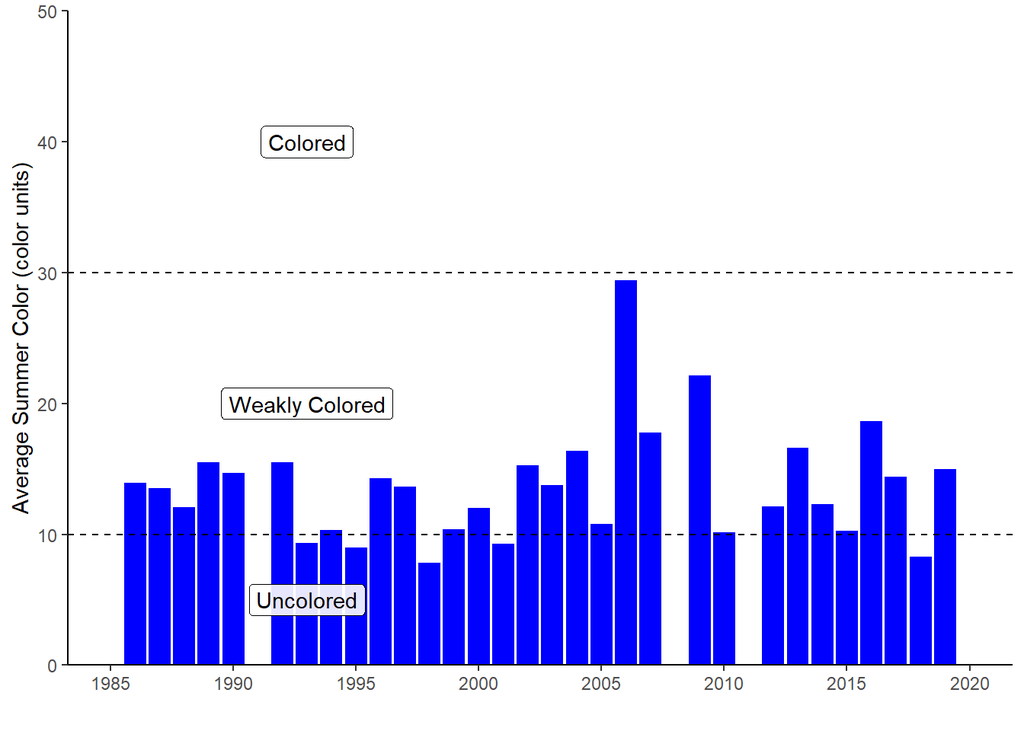

#### Surface and Deep Temperature

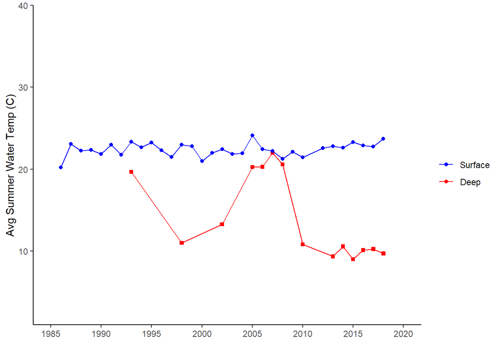

#### Lake Perception

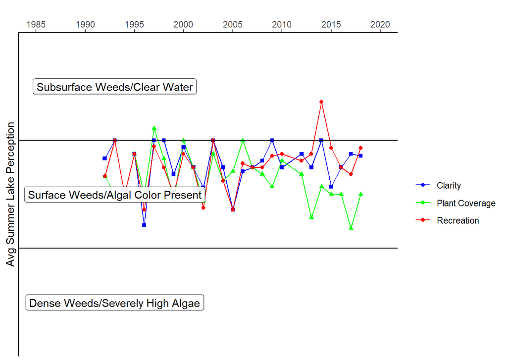

## Butterfield Lake - In-Season Analysis

#### In Season Water Clarity

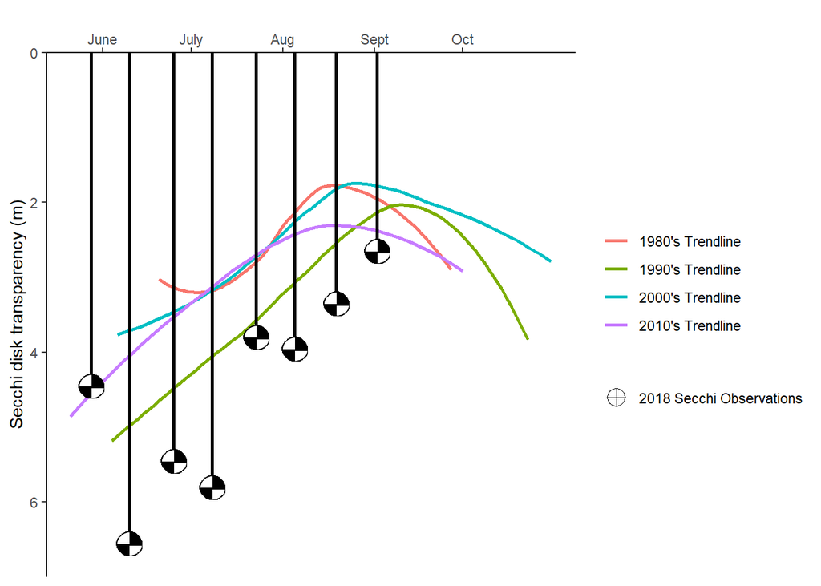

#### In Season Water Temperature

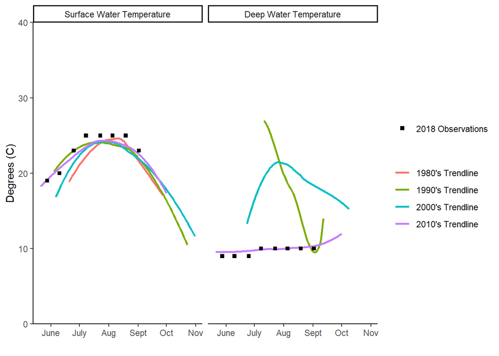